# Part 1: Data Preprocessing - Zomato Bangalore Dataset

## Comparative Analysis of Transformer Models for Aspect-Based Sentiment Analysis

**Dataset:** Zomato Bangalore Restaurant Reviews (~51K restaurants)  
**Source:** https://www.kaggle.com/datasets/himanshupoddar/zomato-bangalore-restaurants

### 📋 What This Notebook Does:

1. Load Zomato Bangalore dataset
2. Extract individual reviews from `reviews_list` column
3. Parse ratings and clean text
4. Create sentiment labels from ratings
5. Extract aspects (Food, Service, Ambiance, Price)
6. Prepare data splits for training

## Step 1: Install & Import Libraries

```python
# Install required packages
!pip install pandas numpy matplotlib seaborn nltk scikit-learn -q

print("✓ Packages installed!")
```

```
✓ Packages installed!
```

```python
# Import libraries
import pandas as pd
import numpy as np
import matplotlib.pyplot as plt
import seaborn as sns
import re
import ast
import warnings
from IPython.display import display

warnings.filterwarnings('ignore')

# Set visualization style
sns.set_style('whitegrid')
plt.rcParams['figure.figsize'] = (12, 6)

print("✓ Libraries imported successfully!")
```

```
✓ Libraries imported successfully!
```

## Step 2: Download NLTK Data

```python
import nltk

print("Downloading NLTK data...")
nltk.download('punkt', quiet=True)
nltk.download('stopwords', quiet=True)
nltk.download('wordnet', quiet=True)
nltk.download('omw-1.4', quiet=True)
print("✓ NLTK data downloaded!")
```

```
Downloading NLTK data...
✓ NLTK data downloaded!
```

## Step 3: Load Dataset

### 📥 Before Running:

1. Download: **[Zomato Bangalore Dataset](https://www.kaggle.com/datasets/himanshupoddar/zomato-bangalore-restaurants)**
2. Upload the CSV file to this notebook directory
3. Update the filename below if needed

```python
# ⚠️ UPDATE THIS with your actual filename
DATASET_PATH = "zomato.csv"

print(f"Loading dataset: {DATASET_PATH}")
print("="*70)

try:
    df = pd.read_csv(DATASET_PATH)
    print(f"✓ Successfully loaded {len(df):,} restaurants\n")

    print(f"Dataset shape: {df.shape}")
    print(f"\nColumns: {list(df.columns)}\n")

    # Display first few rows
    print("First 3 rows:")
    display(df.head(3))

except FileNotFoundError:
    print(f"❌ ERROR: File '{DATASET_PATH}' not found!\n")
    print("Please:")
    print("1. Download from: https://www.kaggle.com/datasets/himanshupoddar/zomato-bangalore-restaurants")
    print("2. Upload CSV to this notebook")
    print("3. Update DATASET_PATH above")
    raise
```

```
Loading dataset: zomato.csv
======================================================================
✓ Successfully loaded 51,717 restaurants

Dataset shape: (51717, 17)

Columns: ['url', 'address', 'name', 'online_order', 'book_table', 'rate', 'votes', 'phone', 'location', 'rest_type', 'dish_liked', 'cuisines', 'approx_cost(for two people)', 'reviews_list', 'menu_item', 'listed_in(type)', 'listed_in(city)']

First 3 rows:
```

|  | url | address | name | online_order | book_table | rate | votes | phone | location | rest_type | dish_liked | cuisines | approx_cost(for two people) | reviews_list | menu_item | listed_in(type) | listed_in(city) |
| --- | --- | --- | --- | --- | --- | --- | --- | --- | --- | --- | --- | --- | --- | --- | --- | --- | --- |
| 0 | https://www.zomato.com/bangalore/jalsa-banasha... | 942, 21st Main Road, 2nd Stage, Banashankari, ... | Jalsa | Yes | Yes | 4.1/5 | 775 | 080 42297555\r\n+91 9743772233 | Banashankari | Casual Dining | Pasta, Lunch Buffet, Masala Papad, Paneer Laja... | North Indian, Mughlai, Chinese | 800 | [('Rated 4.0', 'RATED\n A beautiful place to ... | [] | Buffet | Banashankari |
| 1 | https://www.zomato.com/bangalore/spice-elephan... | 2nd Floor, 80 Feet Road, Near Big Bazaar, 6th ... | Spice Elephant | Yes | No | 4.1/5 | 787 | 080 41714161 | Banashankari | Casual Dining | Momos, Lunch Buffet, Chocolate Nirvana, Thai G... | Chinese, North Indian, Thai | 800 | [('Rated 4.0', 'RATED\n Had been here for din... | [] | Buffet | Banashankari |
| 2 | https://www.zomato.com/SanchurroBangalore?cont... | 1112, Next to KIMS Medical College, 17th Cross... | San Churro Cafe | Yes | No | 3.8/5 | 918 | +91 9663487993 | Banashankari | Cafe, Casual Dining | Churros, Cannelloni, Minestrone Soup, Hot Choc... | Cafe, Mexican, Italian | 800 | [('Rated 3.0', "RATED\n Ambience is not that ... | [] | Buffet | Banashankari |

## Step 4: Explore Dataset

```python
print("📊 DATASET STATISTICS")
print("="*70)

print(f"\nTotal restaurants: {len(df):,}")
print(f"Total columns: {len(df.columns)}")

print("\nMissing values:")
missing = df.isnull().sum()
missing_pct = (missing / len(df) * 100).round(1)
missing_df = pd.DataFrame({'Count': missing, 'Percentage': missing_pct})
display(missing_df[missing_df['Count'] > 0].sort_values('Count', ascending=False))
```

```
📊 DATASET STATISTICS
======================================================================

Total restaurants: 51,717
Total columns: 17

Missing values:
```

|  | Count | Percentage |
| --- | --- | --- |
| dish_liked | 28078 | 54.3 |
| rate | 7775 | 15.0 |
| phone | 1208 | 2.3 |
| approx_cost(for two people) | 346 | 0.7 |
| rest_type | 227 | 0.4 |
| cuisines | 45 | 0.1 |
| location | 21 | 0.0 |

```python
# Clean column names (remove extra spaces and special characters)
df.columns = df.columns.str.strip()
print("✓ Column names cleaned")
print(df.columns.tolist())
```

```
✓ Column names cleaned
['url', 'address', 'name', 'online_order', 'book_table', 'rate', 'votes', 'phone', 'location', 'rest_type', 'dish_liked', 'cuisines', 'approx_cost(for two people)', 'reviews_list', 'menu_item', 'listed_in(type)', 'listed_in(city)']
```

```python
# Check the reviews_list column
print("\n📝 Checking 'reviews_list' column...\n")
print(f"Non-null reviews: {df['reviews_list'].notna().sum():,} / {len(df):,}")
print(f"\nSample review entry:")
print(df['reviews_list'].iloc[0])
```

```
📝 Checking 'reviews_list' column...

Non-null reviews: 51,717 / 51,717

Sample review entry:
[('Rated 4.0', 'RATED\n  A beautiful place to dine in.The interiors take you back to the Mughal era. The lightings are just perfect.We went there on the occasion of Christmas and so they had only limited items available. But the taste and service was not compromised at all.The only complaint is that…
```

## Step 5: Extract Individual Reviews

The `reviews_list` column contains multiple reviews per restaurant as a string representation of a list of tuples:

```
[("Rated 4.0", "Great food!"), ("Rated 3.5", "Good service"), ...]
```

We'll expand this into individual review rows.

```python
def extract_reviews_from_restaurant(row):
    """
    Extract individual reviews from a restaurant's reviews_list.
    Returns a list of dictionaries with review data.
    """
    reviews_data = []

    if pd.isna(row['reviews_list']) or str(row['reviews_list']).strip() == '[]':
        return reviews_data

    try:
        # Convert string representation to actual list
        reviews_list = ast.literal_eval(str(row['reviews_list']))

        for review_tuple in reviews_list:
            if len(review_tuple) >= 2:
                rating_str = str(review_tuple[0])
                review_text = str(review_tuple[1])

                # Extract numeric rating from "Rated 4.0" format
                rating_match = re.search(r'(\d+\.?\d*)', rating_str)

                if rating_match and review_text and review_text.lower() != 'none':
                    rating = float(rating_match.group(1))

                    # Create review entry with restaurant context
                    reviews_data.append({
                        'restaurant_name': row['name'],
                        'review_text': review_text,
                        'rating': rating,
                        'location': row['location'],
                        'cuisines': row['cuisines'],
                        'rest_type': row['rest_type'],
                        'online_order': row['online_order'],
                        'book_table': row['book_table'],
                        'approx_cost': row['approx_cost(for two people)']
                    })
    except Exception as e:
        pass  # Skip malformed entries

    return reviews_data

print("✓ Review extraction function defined")
```

```
✓ Review extraction function defined
```

```python
# Extract all reviews
print("\nExtracting individual reviews from all restaurants...")
print("This may take 2-3 minutes...\n")

all_reviews = []
for idx, row in df.iterrows():
    reviews = extract_reviews_from_restaurant(row)
    all_reviews.extend(reviews)

    if (idx + 1) % 10000 == 0:
        print(f"Processed {idx + 1:,} / {len(df):,} restaurants... Found {len(all_reviews):,} reviews so far")

# Create new dataframe from extracted reviews
reviews_df = pd.DataFrame(all_reviews)

print(f"\n✓ Extraction complete!")
print(f"  Total reviews extracted: {len(reviews_df):,}")
print(f"  From {len(df):,} restaurants")
print(f"  Average reviews per restaurant: {len(reviews_df)/len(df):.1f}")
```

```
Extracting individual reviews from all restaurants...
This may take 2-3 minutes...

Processed 10,000 / 51,717 restaurants... Found 211,358 reviews so far
Processed 20,000 / 51,717 restaurants... Found 447,227 reviews so far
Processed 30,000 / 51,717 restaurants... Found 699,476 reviews so far
Processed 40,000 / 51,717 restaurants... Found 984,747 reviews so far
Processed 50,000 / 51,717 restaurants... Found 1,278,428 reviews so far

✓ Extraction complete!
  Total reviews extracted: 1,317,699
  From 51,717 restaurants
  Average reviews per restaurant: 25.5
```

```python
# Display sample extracted reviews
print("\n📝 Sample Extracted Reviews:")
print("="*70)
display(reviews_df.head(10))
```

```
📝 Sample Extracted Reviews:
======================================================================
```

|  | restaurant_name | review_text | rating | location | cuisines | rest_type | online_order | book_table | approx_cost |
| --- | --- | --- | --- | --- | --- | --- | --- | --- | --- |
| 0 | Jalsa | RATED\n A beautiful place to dine in.The inte... | 4.0 | Banashankari | North Indian, Mughlai, Chinese | Casual Dining | Yes | Yes | 800 |
| 1 | Jalsa | RATED\n I was here for dinner with my family ... | 4.0 | Banashankari | North Indian, Mughlai, Chinese | Casual Dining | Yes | Yes | 800 |
| 2 | Jalsa | RATED\n Its a restaurant near to Banashankari... | 2.0 | Banashankari | North Indian, Mughlai, Chinese | Casual Dining | Yes | Yes | 800 |
| 3 | Jalsa | RATED\n We went here on a weekend and one of ... | 4.0 | Banashankari | North Indian, Mughlai, Chinese | Casual Dining | Yes | Yes | 800 |
| 4 | Jalsa | RATED\n The best thing about the place is itÃ... | 5.0 | Banashankari | North Indian, Mughlai, Chinese | Casual Dining | Yes | Yes | 800 |
| 5 | Jalsa | RATED\n Great food and pleasant ambience. Exp... | 5.0 | Banashankari | North Indian, Mughlai, Chinese | Casual Dining | Yes | Yes | 800 |
| 6 | Jalsa | RATED\n Good ambience with tasty food.\nChees... | 4.0 | Banashankari | North Indian, Mughlai, Chinese | Casual Dining | Yes | Yes | 800 |
| 7 | Jalsa | RATED\n You canÃÂÃÂÃÂÃÂt go w... | 4.0 | Banashankari | North Indian, Mughlai, Chinese | Casual Dining | Yes | Yes | 800 |
| 8 | Jalsa | RATED\n Overdelighted by the service and food... | 5.0 | Banashankari | North Indian, Mughlai, Chinese | Casual Dining | Yes | Yes | 800 |
| 9 | Jalsa | RATED\n The place is nice and comfortable. Fo... | 4.0 | Banashankari | North Indian, Mughlai, Chinese | Casual Dining | Yes | Yes | 800 |

## Step 6: Clean Review Text

```python
def clean_text(text):
    """
    Clean review text.
    """
    if pd.isna(text):
        return ""

    # Convert to string and lowercase
    text = str(text).lower()

    # Remove URLs
    text = re.sub(r'http\S+|www\.\S+', '', text)

    # Remove email addresses
    text = re.sub(r'\S+@\S+', '', text)

    # Remove HTML tags
    text = re.sub(r'<[^>]+>', '', text)

    # Remove special characters but keep punctuation
    text = re.sub(r'[^a-zA-Z0-9\s.,!?\'\-]', '', text)

    # Remove extra whitespace
    text = ' '.join(text.split())

    return text

print("Cleaning review text...")
reviews_df['cleaned_text'] = reviews_df['review_text'].apply(clean_text)

# Remove very short reviews (less than 10 characters)
reviews_df = reviews_df[reviews_df['cleaned_text'].str.len() >= 10].copy()

print(f"✓ Text cleaning completed!")
print(f"  Reviews after cleaning: {len(reviews_df):,}")

# Show examples
print("\n📝 Cleaning Examples:")
print("="*70)
for i in range(3):
    print(f"\nReview {i+1}:")
    print(f"  Original: {reviews_df['review_text'].iloc[i][:100]}...")
    print(f"  Cleaned:  {reviews_df['cleaned_text'].iloc[i][:100]}...")
```

```
Cleaning review text...
✓ Text cleaning completed!
  Reviews after cleaning: 1,313,065

📝 Cleaning Examples:
======================================================================

Review 1:
  Original: RATED
  A beautiful place to dine in.The interiors take you back to the Mughal era. The lightings ar...
  Cleaned:  rated a beautiful place to dine in.the interiors take you back to the mughal era. the lightings are ...

Review 2:
  Original: RATED
  I was here for dinner with my family on a weekday. The restaurant was completely empty. Ambi...
  Cleaned:  rated i was here for dinner with my family on a weekday. the restaurant was completely empty. ambien...

Review 3:
  Original: RATED
  Its a restaurant near to Banashankari BDA. Me along with few of my office friends visited to...
  Cleaned:  rated its a restaurant near to banashankari bda. me along with few of my office friends visited to h...
```

## Step 7: Create Sentiment Labels

Convert ratings (typically 1-5) to sentiment:

- **Positive:** 4-5 stars
- **Neutral:** 3 stars
- **Negative:** 1-2 stars

```python
# Check rating distribution
print("Rating Distribution:")
print("="*70)
print(reviews_df['rating'].value_counts().sort_index())
print(f"\nRating range: {reviews_df['rating'].min()} - {reviews_df['rating'].max()}")
```

```
Rating Distribution:
======================================================================
rating
1.0    152959
1.5      9647
2.0     66730
2.5     17865
3.0    179871
3.5     56672
4.0    400887
4.5     51182
5.0    377252
Name: count, dtype: int64

Rating range: 1.0 - 5.0
```

```python
def create_sentiment_label(rating):
    """
    Convert rating to sentiment label.
    """
    if pd.isna(rating):
        return 'neutral'

    rating = float(rating)

    if rating >= 4:
        return 'positive'
    elif rating <= 2:
        return 'negative'
    else:
        return 'neutral'

# Create sentiment labels
print("\nCreating sentiment labels...\n")
reviews_df['sentiment'] = reviews_df['rating'].apply(create_sentiment_label)

# Create numeric labels
label_map = {'negative': 0, 'neutral': 1, 'positive': 2}
reviews_df['label'] = reviews_df['sentiment'].map(label_map)

print("✓ Sentiment labels created!\n")

# Show distribution
print("Sentiment Distribution:")
print("="*70)
sentiment_counts = reviews_df['sentiment'].value_counts()
for sentiment in ['positive', 'neutral', 'negative']:
    count = sentiment_counts.get(sentiment, 0)
    pct = count / len(reviews_df) * 100
    print(f"  {sentiment.capitalize():10}: {count:6,} reviews ({pct:5.1f}%)")

print(f"\n  Total: {len(reviews_df):,} reviews")
```

```
Creating sentiment labels...

✓ Sentiment labels created!

Sentiment Distribution:
======================================================================
  Positive  : 829,321 reviews ( 63.2%)
  Neutral   : 254,408 reviews ( 19.4%)
  Negative  : 229,336 reviews ( 17.5%)

  Total: 1,313,065 reviews
```

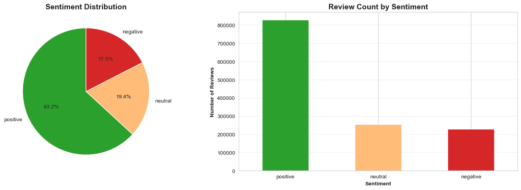

```python
# Visualize sentiment distribution
fig, (ax1, ax2) = plt.subplots(1, 2, figsize=(15, 5))

# Pie chart
colors = ['#2ca02c', '#ffbb78', '#d62728']
sentiment_counts = reviews_df['sentiment'].value_counts()
ax1.pie(sentiment_counts, labels=sentiment_counts.index, autopct='%1.1f%%',
        colors=colors, startangle=90)
ax1.set_title('Sentiment Distribution', fontweight='bold', fontsize=14)

# Bar chart
sentiment_counts.plot(kind='bar', ax=ax2, color=colors)
ax2.set_title('Review Count by Sentiment', fontweight='bold', fontsize=14)
ax2.set_xlabel('Sentiment', fontweight='bold')
ax2.set_ylabel('Number of Reviews', fontweight='bold')
ax2.set_xticklabels(ax2.get_xticklabels(), rotation=0)
ax2.grid(axis='y', alpha=0.3)

plt.tight_layout()
plt.show()
```

## Step 8: Extract Aspects

Identify mentions of:

- **Food:** Quality, taste, dishes
- **Service:** Staff, waiters, attention
- **Ambiance:** Atmosphere, decor
- **Price:** Value, cost

```python
# Define aspect keywords
ASPECT_KEYWORDS = {
    'food': [
        'food', 'dish', 'dishes', 'meal', 'taste', 'flavor', 'flavour',
        'delicious', 'tasty', 'yummy', 'cuisine', 'menu', 'plate',
        'recipe', 'ingredient', 'cooked', 'fresh', 'quality',
        'pizza', 'pasta', 'biryani', 'dosa', 'idli', 'curry',
        'burger', 'sandwich', 'soup', 'dessert', 'sweet'
    ],
    'service': [
        'service', 'waiter', 'waiters', 'waitress', 'staff', 'server',
        'friendly', 'attentive', 'helpful', 'professional', 'courteous',
        'rude', 'slow', 'quick', 'fast', 'efficient', 'prompt',
        'wait', 'waited', 'waiting', 'attention', 'manager', 'hospitality'
    ],
    'ambiance': [
        'ambiance', 'ambience', 'atmosphere', 'decor', 'decoration',
        'environment', 'setting', 'vibe', 'music', 'lighting',
        'comfortable', 'cozy', 'romantic', 'casual', 'elegant',
        'noisy', 'loud', 'quiet', 'crowded', 'spacious', 'interior',
        'seating', 'tables', 'view', 'place'
    ],
    'price': [
        'price', 'prices', 'expensive', 'cheap', 'value', 'worth',
        'cost', 'costs', 'affordable', 'overpriced', 'reasonable',
        'budget', 'money', 'pricey', 'bill', 'pay', 'paid',
        'rupees', 'rs'
    ]
}

print("Aspect Keywords Defined:")
print("="*70)
for aspect, keywords in ASPECT_KEYWORDS.items():
    print(f"  {aspect.capitalize():10}: {len(keywords)} keywords")
```

```
Aspect Keywords Defined:
======================================================================
  Food      : 29 keywords
  Service   : 23 keywords
  Ambiance  : 25 keywords
  Price     : 19 keywords
```

```python
# Extract aspects
print("\nExtracting aspects from reviews...\n")

for aspect, keywords in ASPECT_KEYWORDS.items():
    reviews_df[f'has_{aspect}'] = reviews_df['cleaned_text'].apply(
        lambda x: any(keyword in str(x).lower() for keyword in keywords)
    )

print("✓ Aspect extraction completed!\n")

# Show statistics
print("Aspect Mention Statistics:")
print("="*70)
aspect_stats = {}
for aspect in ASPECT_KEYWORDS.keys():
    count = reviews_df[f'has_{aspect}'].sum()
    pct = count / len(reviews_df) * 100
    aspect_stats[aspect] = count
    print(f"  {aspect.capitalize():10}: {count:6,} reviews ({pct:5.1f}%)")

# Count multi-aspect reviews
reviews_df['aspect_count'] = sum(reviews_df[f'has_{aspect}'] for aspect in ASPECT_KEYWORDS.keys())
multi_aspect = (reviews_df['aspect_count'] > 1).sum()
print(f"\n  Multi-aspect reviews: {multi_aspect:,} ({multi_aspect/len(reviews_df)*100:.1f}%)")
```

```
Extracting aspects from reviews...

✓ Aspect extraction completed!

Aspect Mention Statistics:
======================================================================
  Food      : 1,085,798 reviews ( 82.7%)
  Service   : 589,503 reviews ( 44.9%)
  Ambiance  : 812,097 reviews ( 61.8%)
  Price     : 678,226 reviews ( 51.7%)

  Multi-aspect reviews: 1,002,783 (76.4%)
```

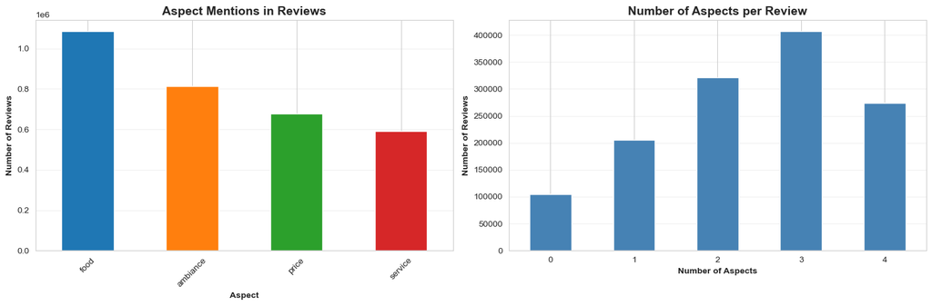

```python
# Visualize aspects
fig, axes = plt.subplots(1, 2, figsize=(15, 5))

# Aspect mentions
aspect_df = pd.Series(aspect_stats).sort_values(ascending=False)
colors_aspects = ['#1f77b4', '#ff7f0e', '#2ca02c', '#d62728']
aspect_df.plot(kind='bar', ax=axes[0], color=colors_aspects)
axes[0].set_title('Aspect Mentions in Reviews', fontweight='bold', fontsize=14)
axes[0].set_xlabel('Aspect', fontweight='bold')
axes[0].set_ylabel('Number of Reviews', fontweight='bold')
axes[0].set_xticklabels(axes[0].get_xticklabels(), rotation=45)
axes[0].grid(axis='y', alpha=0.3)

# Aspect count distribution
aspect_count_dist = reviews_df['aspect_count'].value_counts().sort_index()
aspect_count_dist.plot(kind='bar', ax=axes[1], color='steelblue')
axes[1].set_title('Number of Aspects per Review', fontweight='bold', fontsize=14)
axes[1].set_xlabel('Number of Aspects', fontweight='bold')
axes[1].set_ylabel('Number of Reviews', fontweight='bold')
axes[1].set_xticklabels(axes[1].get_xticklabels(), rotation=0)
axes[1].grid(axis='y', alpha=0.3)

plt.tight_layout()
plt.show()
```

```python
# Show example reviews by aspect
print("\n📝 Example Reviews by Aspect:")
print("="*70)

for aspect in ASPECT_KEYWORDS.keys():
    sample = reviews_df[reviews_df[f'has_{aspect}'] == True]['review_text'].head(2)

    if len(sample) > 0:
        print(f"\n{aspect.upper()}:")
        for i, review in enumerate(sample, 1):
            print(f"  {i}. {review[:120]}...")
        print("-" * 70)
```

```
📝 Example Reviews by Aspect:
======================================================================

FOOD:
  1. RATED
  A beautiful place to dine in.The interiors take you back to the Mughal era. The lightings are just perfect.We we...
  2. RATED
  I was here for dinner with my family on a weekday. The restaurant was completely empty. Ambience is good with so...
----------------------------------------------------------------------

SERVICE:
  1. RATED
  A beautiful place to dine in.The interiors take you back to the Mughal era. The lightings are just perfect.We we...
  2. RATED
  I was here for dinner with my family on a weekday. The restaurant was completely empty. Ambience is good with so...
----------------------------------------------------------------------

AMBIANCE:
  1. RATED
  A beautiful place to dine in.The interiors take you back to the Mughal era. The lightings are just perfect.We we...
  2. RATED
  I was here for dinner with my family on a weekday. The restaurant was completely empty. Ambience is good with so...
----------------------------------------------------------------------

PRICE:
  1. RATED
  A beautiful place to dine in.The interiors take you back to the Mughal era. The lightings are just perfect.We we...
  2. RATED
  I was here for dinner with my family on a weekday. The restaurant was completely empty. Ambience is good with so...
----------------------------------------------------------------------
```

## Step 9: Aspect-Sentiment Analysis

```python
# Sentiment distribution by aspect
print("\n📊 Sentiment Distribution by Aspect:")
print("="*70)

aspect_sentiment_data = []

for aspect in ASPECT_KEYWORDS.keys():
    aspect_reviews = reviews_df[reviews_df[f'has_{aspect}'] == True]

    if len(aspect_reviews) > 0:
        sentiment_dist = aspect_reviews['sentiment'].value_counts(normalize=True) * 100

        print(f"\n{aspect.capitalize()}:")
        for sentiment in ['positive', 'neutral', 'negative']:
            pct = sentiment_dist.get(sentiment, 0)
            print(f"  {sentiment:10}: {pct:5.1f}%")

        aspect_sentiment_data.append({
            'Aspect': aspect.capitalize(),
            'Positive': sentiment_dist.get('positive', 0),
            'Neutral': sentiment_dist.get('neutral', 0),
            'Negative': sentiment_dist.get('negative', 0)
        })
```

```
📊 Sentiment Distribution by Aspect:
======================================================================

Food:
  positive  :  65.0%
  neutral   :  20.0%
  negative  :  15.0%

Service:
  positive  :  68.1%
  neutral   :  20.4%
  negative  :  11.5%

Ambiance:
  positive  :  69.7%
  neutral   :  21.3%
  negative  :   9.0%

Price:
  positive  :  62.5%
  neutral   :  21.0%
  negative  :  16.5%
```

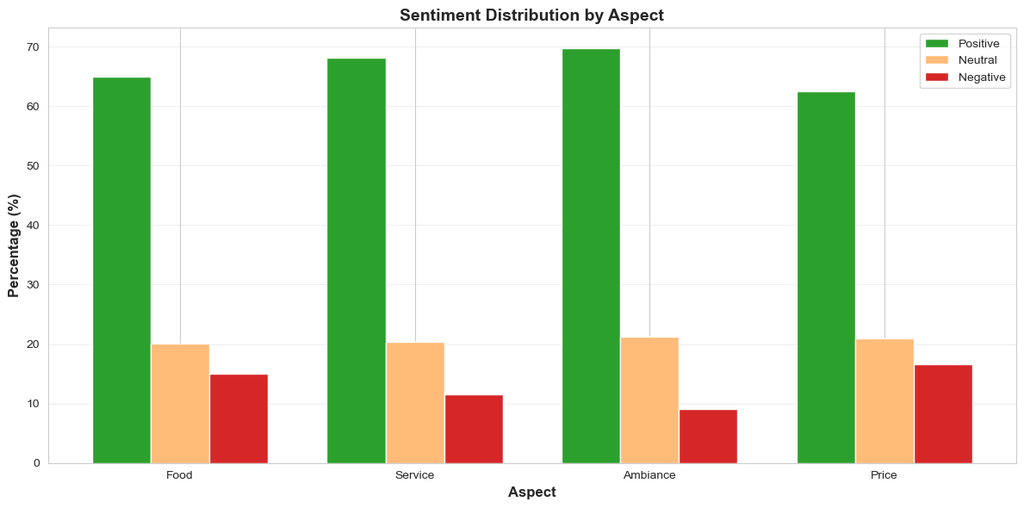

```python
# Visualize aspect-sentiment relationship
aspect_sent_df = pd.DataFrame(aspect_sentiment_data)

fig, ax = plt.subplots(figsize=(12, 6))

x = np.arange(len(aspect_sent_df))
width = 0.25

ax.bar(x - width, aspect_sent_df['Positive'], width, label='Positive', color='#2ca02c')
ax.bar(x, aspect_sent_df['Neutral'], width, label='Neutral', color='#ffbb78')
ax.bar(x + width, aspect_sent_df['Negative'], width, label='Negative', color='#d62728')

ax.set_xlabel('Aspect', fontweight='bold', fontsize=12)
ax.set_ylabel('Percentage (%)', fontweight='bold', fontsize=12)
ax.set_title('Sentiment Distribution by Aspect', fontweight='bold', fontsize=14)
ax.set_xticks(x)
ax.set_xticklabels(aspect_sent_df['Aspect'])
ax.legend()
ax.grid(axis='y', alpha=0.3)

plt.tight_layout()
plt.show()
```

## Step 10: Data Splitting

```python
from sklearn.model_selection import train_test_split

print("Splitting data: 70% train, 15% validation, 15% test...\n")

# First split: 70% train, 30% temp
train_df, temp_df = train_test_split(
    reviews_df,
    test_size=0.3,
    random_state=42,
    stratify=reviews_df['label']
)

# Second split: 15% validation, 15% test
val_df, test_df = train_test_split(
    temp_df,
    test_size=0.5,
    random_state=42,
    stratify=temp_df['label']
)

print("✓ Data split completed!\n")
print("Split Summary:")
print("="*70)
print(f"  Training:   {len(train_df):6,} reviews ({len(train_df)/len(reviews_df)*100:5.1f}%)")
print(f"  Validation: {len(val_df):6,} reviews ({len(val_df)/len(reviews_df)*100:5.1f}%)")
print(f"  Test:       {len(test_df):6,} reviews ({len(test_df)/len(reviews_df)*100:5.1f}%)")
print(f"  Total:      {len(reviews_df):6,} reviews")

# Check distribution
print("\nSentiment Distribution in Splits:")
print("="*70)
for name, dataset in [('Train', train_df), ('Val', val_df), ('Test', test_df)]:
    print(f"\n{name}:")
    for sentiment in ['positive', 'neutral', 'negative']:
        count = (dataset['sentiment'] == sentiment).sum()
        pct = count / len(dataset) * 100
        print(f"  {sentiment:10}: {count:5,} ({pct:5.1f}%)")
```

```
Splitting data: 70% train, 15% validation, 15% test...

✓ Data split completed!

Split Summary:
======================================================================
  Training:   919,145 reviews ( 70.0%)
  Validation: 196,960 reviews ( 15.0%)
  Test:       196,960 reviews ( 15.0%)
  Total:      1,313,065 reviews

Sentiment Distribution in Splits:
======================================================================

Train:
  positive  : 580,524 ( 63.2%)
  neutral   : 178,086 ( 19.4%)
  negative  : 160,535 ( 17.5%)

Val:
  positive  : 124,399 ( 63.2%)
  neutral   : 38,161 ( 19.4%)
  negative  : 34,400 ( 17.5%)

Test:
  positive  : 124,398 ( 63.2%)
  neutral   : 38,161 ( 19.4%)
  negative  : 34,401 ( 17.5%)
```

## Step 11: Save Preprocessed Data

```python
# Save full preprocessed dataset
output_file = 'zomato_reviews_preprocessed.csv'
reviews_df.to_csv(output_file, index=False)
print(f"✓ Full dataset saved: {output_file}")
print(f"  Rows: {len(reviews_df):,}")
print(f"  Columns: {len(reviews_df.columns)}")

# Save splits
train_df.to_csv('train_data.csv', index=False)
val_df.to_csv('val_data.csv', index=False)
test_df.to_csv('test_data.csv', index=False)

print(f"\n✓ Data splits saved:")
print(f"  - train_data.csv ({len(train_df):,} rows)")
print(f"  - val_data.csv ({len(val_df):,} rows)")
print(f"  - test_data.csv ({len(test_df):,} rows)")
```

```
✓ Full dataset saved: zomato_reviews_preprocessed.csv
  Rows: 1,313,065
  Columns: 17

✓ Data splits saved:
  - train_data.csv (919,145 rows)
  - val_data.csv (196,960 rows)
  - test_data.csv (196,960 rows)
```

## Step 12: Final Summary

```python
print("\n" + "="*70)
print("📊 PREPROCESSING SUMMARY")
print("="*70)

print(f"\n✓ Dataset: Zomato Bangalore Restaurant Reviews")
print(f"✓ Source restaurants: {len(df):,}")
print(f"✓ Total reviews extracted: {len(reviews_df):,}")
print(f"✓ Average reviews per restaurant: {len(reviews_df)/len(df):.1f}")

print(f"\n✓ Sentiment Distribution:")
for sentiment, count in reviews_df['sentiment'].value_counts().items():
    print(f"    {sentiment.capitalize()}: {count:,} ({count/len(reviews_df)*100:.1f}%)")

print(f"\n✓ Aspect Coverage:")
for aspect in ASPECT_KEYWORDS.keys():
    count = reviews_df[f'has_{aspect}'].sum()
    print(f"    {aspect.capitalize()}: {count:,} ({count/len(reviews_df)*100:.1f}%)")

print(f"\n✓ Data Splits:")
print(f"    Train: {len(train_df):,} | Val: {len(val_df):,} | Test: {len(test_df):,}")

print("\n" + "="*70)
print("✅ PREPROCESSING COMPLETE!")
print("="*70)
print("\nNext: Open Part2_Train_Models.ipynb to train BERT, RoBERTa, XLM-RoBERTa!")
print("="*70)
```

```
======================================================================
📊 PREPROCESSING SUMMARY
======================================================================

✓ Dataset: Zomato Bangalore Restaurant Reviews
✓ Source restaurants: 51,717
✓ Total reviews extracted: 1,313,065
✓ Average reviews per restaurant: 25.4

✓ Sentiment Distribution:
    Positive: 829,321 (63.2%)
    Neutral: 254,408 (19.4%)
    Negative: 229,336 (17.5%)

✓ Aspect Coverage:
    Food: 1,085,798 (82.7%)
    Service: 589,503 (44.9%)
    Ambiance: 812,097 (61.8%)
    Price: 678,226 (51.7%)

✓ Data Splits:
    Train: 919,145 | Val: 196,960 | Test: 196,960

======================================================================
✅ PREPROCESSING COMPLETE!
======================================================================

Next: Open Part2_Train_Models.ipynb to train BERT, RoBERTa, XLM-RoBERTa!
======================================================================
```

## 🎉 Part 1 Complete!

### What You've Accomplished:

✅ Loaded Zomato Bangalore dataset (51K restaurants)  
✅ Extracted individual reviews from `reviews_list` column  
✅ Parsed ratings and cleaned text  
✅ Created sentiment labels (positive/neutral/negative)  
✅ Extracted 4 aspects (Food, Service, Ambiance, Price)  
✅ Analyzed aspect-sentiment relationships  
✅ Split data (70/15/15)  
✅ Saved preprocessed files

### Files Created:

- `zomato_reviews_preprocessed.csv` - Full dataset
- `train_data.csv` - Training set
- `val_data.csv` - Validation set
- `test_data.csv` - Test set